[figure not shown]

## Proyecto 02

#### **Estudiante:** Merian Herrera Fuentes

```r
library("FactoMineR")
library("corrplot")
library("ggcorrplot")
library("corrr")
library("rattle")
library("fmsb")
library("ggmap")
library("mapproj")
library("factoextra")
```

#### **I Parte: Algoritmo de recomendación**

**1. [20 puntos] Se le pidió a un grupo de 100 clientes que compraron el mismo producto o productos similares en la tienda de AMAZON, que evaluaran el servicio recibido desde diferentes aspectos. El archivo EjemploAlgoritmosRecomendacion.csv muestra los promedios de la evaluación dada por los clientes en relación a las variables que se pueden apreciar en el encabezado de la tabla. Para este dataset, realice lo siguiente:**

**a) Cargue el dataset EjemploAlgoritmosRecomendacion.csv, verifique que la lectura de los datos es correcta.**

```r
clientes <- read.csv("EjemploAlgoritmosRecomendacion.csv", sep = ";", dec = ",", header = T,row.names = 1)
head(clientes)
```

**b) A manera de diagnóstico, haga una inspección de los datos presentes en el dataset y describa las variables presentes, tipos de variables, si hay datos nulos.**

```r
#str(clientes)
sapply(clientes, typeof)
```

**c) Determine si existen correlaciones importantes entre las variables del dataset, utilizando alguno de los gráficos o la matriz de correlaciones vistos en clases (si desea, puede usar otra herramienta de su preferencia). Recordemos que para aplicar un ACP, es importante que existan correlaciones entre las variables.**  
A continuación se muestran las correlaciones numericas para el dataset clientes:

```r
# Para ver las correlaciones numéricas
correlaciones_numericas <- round(cor(clientes), 2)
correlaciones_numericas
```

[output not shown]

```r
corrplot(correlaciones_numericas)
```

[output not shown]

```r
ggcorrplot(correlaciones_numericas)
```

[output not shown]

> Las correlaciones **positivas** más fuertes que se observan son:  
> - **Imagen del producto** con **Servicio de Retorno**  
> - **Número de estrellas** con **valor educativo**  
> - **Número de estrellas** con **velocidad de entrega**  
> - **Velocidad de entrega** con **calidad del producto**  
> Las correlaciones **negativas** más fuertes que se observan son:  
> - **Precio** con **durabilidad**  
> - **Tamaño del paquete** con **velocidad de entrega**  
> - **Tamaño del paquete** con **durabilidad**

**d) Realice un ACP usando el paquete FactoMiner, creando el plano principal y el círculo de correlaciones. Superponga ambos gráficos e identifique la cantidad de clústeres que considere apropiado. Haga un análisis descriptivo de cada clúster, indique si hay variables correlacionadas y el tipo de correlación entre estas.**

```r
pca_clientes <- PCA(clientes, scale.unit=TRUE, ncp=5, graph = FALSE)
plot(pca_clientes, axes=c(1, 2), choix="ind", col.ind="purple",new.plot=TRUE)
```

[output not shown]

```r
plot(pca_clientes, axes=c(1, 2), choix="var", col.var="blue",new.plot=TRUE)
```

[output not shown]

```r
fviz_pca_biplot(pca_clientes, repel = FALSE,
                col.var = "#fc078a", # Variables color
                col.ind = "#696969"  # Individuals color
                )
```

[output not shown]

> Se pueden observar **2 clústeres** bien marcados, cada uno de estos por una correlacion negativa entre el tamaño del paquete y la durabilidad. Podriamos decir que cada grupo de personas representados por un cluster opinaron de manera muy similar en las evaluaciones.  
> **Clúster 01:** En este primer cluster podemos observar al grupo de personas que valora de una manera mas alta el tamano del paquete, de este primer cluster tambien podemos deducir que este grupo de personas valora de una manera positiva variables como el precio, imagen del producto y servicio de retorno. Tambien se observa una correlacion positiva muy fuerte entre la imagen del producto y el servicio de retorno.  
> **Clúster 02:** En este segundo grupo de personas podemos encontrar a quienes valoran de una manera mas positiva la durabilidad del producto, estas personas tambien le dan mas importancia a la velocidad de entrega y calidad del producto, Se observa una correlacion positiva fuerte entre calidad del producto y numero de estrellas, lo que nos iindica que a mayor calidad del producto mayor numero de estrellas.

**e) Repita el ejercicio anterior usando el paquete FactoMineR, elimine de los gráficos los individuos con $cos^{2} (\theta)$ $\le 0.2$ y las variables $cos^{2} (\theta)$ $\le 0.55$ y vuelva a crear el plano principal y el círculo de correlaciones. ¿Cuáles individuos quedaron mal representados?, ¿cuáles variables quedaron mal representadas?**

Sugerencia: Puede usar el código del documento o cualquiera de su preferencia:

**¿Cuáles individuos quedaron mal representados?**

```r
# El coseno cuadrado se calcula sumando los valores de las dos dimensiones por individuo o por variable (puede revisar la presentación, en las diapositivas finales se explica como se calcula este dato

# Se parte del hecho de que ya se tiene el modelo de ACP, que hemos llamado para efectos del ejemplo pca_clientes, de ahí se extrae los cosenos cuadrados de los individuos. Para el caso de las variables, debe cambiar la instrucción pca_datos$ind$cos2 por pca_clientes$var$cos2
cos2.ind<-(pca_clientes$ind$cos2[,1] + pca_clientes$ind$cos2[,2])

individuos_malrepresentados <- NULL

for (i in 1 : nrow(clientes)) {
  ifelse(cos2.ind [i] <= 0.2, individuos_malrepresentados <- rbind(individuos_malrepresentados, i), NA)
}

cos2.ind[individuos_malrepresentados]
```

[output not shown]

```r
#plot(pca_clientes, axes=c(1, 2), choix="ind", col.ind="red",new.plot=TRUE, select="cos2 0.2")
```

```r
#res.pca <- prcomp(clientes, scale = TRUE)
fviz_pca_ind(pca_clientes,
             col.ind = "cos2", # Color by the quality of representation
             gradient.cols = c("#00AFBB", "#E7B800", "#fc078a"),
             repel = FALSE     # Avoid text overlapping
             )
```

[output not shown]

> Los individuos que están mal representados son:  
> - Henry  
> - Isabelle  
> - Sebastian  
> Ya que si calculamos el coseno cuadrado de sus coeficientes de relación todos los resultados son menores a 0.2

**¿Cuáles variables quedaron mal representadas?**

```r
cos2.var<-(pca_clientes$var$cos2[,1] + pca_clientes$var$cos2[,2])

variables_malrepresentadas <- NULL
for (i in 1 : ncol(clientes)) {
  header <- names(cos2.var[i])[1]
  value <- cos2.ind[i]
 ifelse(value <= 0.55, variables_malrepresentadas <- cbind(matrix(c(header, value), 2, 1, TRUE), variables_malrepresentadas), NA)
}
variables_malrepresentadas
```

[output not shown]

```r
# plot(pca_clientes, axes=c(1, 2), choix="var", col.var="blue",new.plot=TRUE, select="cos2 0.55")
```

```r
fviz_pca_var(pca_clientes,
             col.var = "cos2", # Color by contributions to the PC
             gradient.cols = c("#00AFBB", "#E7B800", "#fc078a"),
             repel = TRUE     # Avoid text overlapping
             )
```

[output not shown]

**f) Realice un gráfico radar (araña) usando 3 clústeres e interprete cada uno de los clústeres.**

```r
modelo <- hclust(dist(clientes),method= "ward")
```

```r
centros<-centers.hclust(clientes,modelo,nclust=3,use.median=FALSE)
centros
```

[output not shown]

```r
rownames(centros)<-c("Cluster 1","Cluster 2","Cluster 3")
centros<-as.data.frame(centros)
maximos<-apply(centros,2,max)
minimos<-apply(centros,2,min)
centros<-rbind(minimos,centros)
centros<-rbind(maximos,centros)
centros
```

```r
radarchart(centros,maxmin=TRUE,axistype=4,axislabcol="slategray4",
           centerzero=FALSE,seg=8,cglcol="gray67",
           pcol=c("#00AFBB", "#E7B800", "#fc078a"),
           plty=1,
           plwd=5,
           title="Comparacion de clusteres")

legenda <-legend(1.5,1, legend=c("Cluster 1","Cluster 2","Cluster 3"),
                 seg.len=-1.4,
                 title="Clusteres",
                 pch=21,
                 bty="n" ,lwd=3, y.intersp=1, horiz=FALSE,
                 col=c("#00AFBB", "#E7B800", "#fc078a"))
```

[output not shown]

**g) Suponga que se trabajaron los datos con 3 clústeres, como se muestra en el plano principal siguiente:**

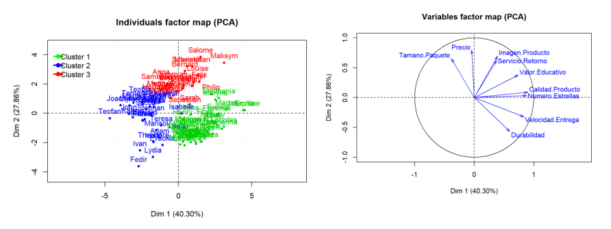

Partiendo del hecho de que todos los individuos compraron, ya sea el mismo producto o similares, pero, cada uno tuvo una experiencia de compra diferente que pudo ser mejor o peor en los diferentes rubros de la evaluación,

• ¿Qué productos recomendaría a Salome?

> Salome se encuentra representado en el cluster 3, donde tambien se encuentran representados otros individuos que le dan mayor valor a las mismas variables que Salome, por lo tanto, se recomienda a Salome comprar los mismos productos adquiridos por personas dentro de este cluster como: Maksym, Louise, Philip…

**• ¿Qué productos recomendaría a Stephania?**

> A Stephania la vemos representada en el cluster 1, donde tambien vemos representados a individuos como Maryna, Eunice y Marcel Se recomienda a Stephania adquirir productos que han comprado algunos de los individuos mencionados previamente o productos adquiridos por cualquiera de los individuos representados en el cluster 1.

**• ¿Qué productos recomendaría a Lydia?**

> Lydia por su parte esta representada dentro del cluster 2, dentro de este cluster tambien vemos representados a Ivan, Fedir, Evdokia… Al igual que los individuos representados en los clusters 1 y 3, se recomienda a Lydia comprar productos que han sido adquiridos por los individuos representados en el cluster que la representa, en este caso el cluster 2.

**Es decir, los mismos productos que compró cuál otro cliente.**

#### **II PARTE: resuelva la siguiente situación**

**1. [10 puntos] Considérese tabla datos ConsumoEuropa.csv que contiene una estimación del consumo promedio de proteínas, en gramos, por persona y por día, en Europa, datos del año 1981 (Está en el aula virtual con el nombre).**

```r
consumo <- read.csv("ConsumoEuropa.csv", sep = ";", dec = ",", header = T,row.names = 1)
#print(dim(consumo))
head(consumo, 50)
```

|  | CarneAnimal | CarneCerdo | Huevos | Leche | CarnePescado | Cereales | Almidon | Semillas | Frutas |
| --- | --- | --- | --- | --- | --- | --- | --- | --- | --- |
| Albania | 10.1 | 1.4 | 0.5 | 8.9 | 0.2 | 42.3 | 0.6 | 5.5 | 1.7 |
| Austria | 8.9 | 14.0 | 4.3 | 19.9 | 2.1 | 28.0 | 3.6 | 1.3 | 4.3 |
| Belgica | 13.5 | 9.3 | 4.1 | 17.5 | 4.5 | 26.6 | 5.7 | 2.1 | 4.0 |
| Bulgaria | 7.8 | 6.0 | 1.6 | 8.3 | 1.2 | 56.7 | 1.1 | 3.7 | 4.2 |
| Checoslovaquia | 9.7 | 11.4 | 2.8 | 12.5 | 2.0 | 34.3 | 5.0 | 1.1 | 4.0 |
| Dinamarca | 10.6 | 10.8 | 3.7 | 25.0 | 9.9 | 21.9 | 4.8 | 0.7 | 2.4 |
| Alemania Or. | 8.4 | 11.6 | 3.7 | 11.1 | 5.4 | 24.6 | 6.5 | 0.8 | 3.6 |
| Finlandia | 9.5 | 4.9 | 2.7 | 33.7 | 5.8 | 26.3 | 5.1 | 1.0 | 1.4 |
| Francia | 18.0 | 9.9 | 3.3 | 19.5 | 5.7 | 28.1 | 4.8 | 2.4 | 6.5 |
| Grecia | 10.2 | 3.0 | 2.8 | 17.6 | 5.9 | 41.7 | 2.2 | 7.8 | 6.5 |

[output cut: 15 more lines]

**a. Usando FactoMineR efectúe un ACP para esta tabla de datos.**

```r
pca_consumo <- PCA(consumo, scale.unit=TRUE, ncp=5, graph = FALSE)
typeof(pca_consumo)
```

```
[1] "list"
```

```r
print(pca_consumo)
```

```
**Results for the Principal Component Analysis (PCA)**
The analysis was performed on 25 individuals, described by 9 variables
*The results are available in the following objects:

   name               description
1  "$eig"             "eigenvalues"
2  "$var"             "results for the variables"
3  "$var$coord"       "coord. for the variables"
4  "$var$cor"         "correlations variables - dimensions"
5  "$var$cos2"        "cos2 for the variables"
6  "$var$contrib"     "contributions of the variables"
7  "$ind"             "results for the individuals"
8  "$ind$coord"       "coord. for the individuals"
9  "$ind$cos2"        "cos2 for the individuals"
10 "$ind$contrib"     "contributions of the individuals"
11 "$call"            "summary statistics"
12 "$call$centre"     "mean of the variables"
13 "$call$ecart.type" "standard error of the variables"
14 "$call$row.w"      "weights for the individuals"
15 "$call$col.w"      "weights for the variables"
```

```r
#pca_consumo$var$coord
pca_consumo$ind
```

```
$coord
                     Dim.1      Dim.2       Dim.3       Dim.4       Dim.5
Albania        -3.52882318 -1.6495797  1.68095521 -0.84628008 -0.61951565
Austria         1.53063492 -1.0817267 -1.13675145  0.72281488 -0.79003008
Belgica         1.71914565  0.1655061  0.17472339  0.37258728  0.39769626
Bulgaria       -3.11680929 -1.3561751 -0.09782412  0.19230035 -0.71584431
Checoslovaquia  0.47952549 -0.5653280 -1.22366940 -0.07410581 -0.12608640
Dinamarca       2.38110229  0.3334138  0.28676001 -1.21783363 -0.61886285
Alemania Or.    1.55090096  0.5765590 -1.55491932 -0.68985209 -0.05956403
Finlandia       1.47720513 -0.6461860  1.15518885 -1.95387702  0.83642412
Francia         1.57865955  0.7001927  1.01827989  1.68881620 -0.05533246
Grecia         -2.27623339  0.8033737  1.57550047  1.56238238  0.19401518
Hungria        -1.35688965 -0.8616559 -1.84319200  0.67265424  0.04136949
Irlanda         2.74540240 -0.8108904  0.30750872  0.27298171  1.03434501
Italia         -1.50694772  0.2894159  0.42517558  1.29192435 -0.60881383
Holanda         1.71610319 -0.9611888 -0.75890894  0.26825105 -0.47252056
Noruega        -0.02522478  1.5697518  0.24587092 -1.77799450 -1.03373888
Polonia         0.18200361  0.4458246 -1.56462525  0.56701581  0.67220095
Portugal       -1.70235674  4.3700728 -0.32732630 -0.55581371 -0.35655444
Rumania        -2.75543311 -1.1643799 -0.39099181 -0.51016754  0.35238284
Espana         -1.26484877  2.5285620 -0.20392365  0.72332290  0.68009665
Suecia          1.62318588 -0.1801459  0.84286765 -1.26543585 -0.69211006
Suiza           0.95548574 -0.8677080  0.66299854  1.03222560 -0.65238008
Reino Unido     1.80073260 -0.1363028  1.98960143  0.76377890  0.56688768
URSS           -0.77803248 -0.1260440 -0.04188092 -0.97987454  1.74353358
Alemania Occ.   2.20827159 -0.2769023 -0.58313341  0.29045069 -0.28687076
Yugoslavia     -3.63675989 -1.0984587 -0.63828409 -0.55027158  0.56927264

$cos2
                      Dim.1       Dim.2        Dim.3       Dim.4        Dim.5
Albania        6.134720e-01 0.134054535 0.1392025573 0.035282810 0.0189077343
Austria        3.709304e-01 0.185261141 0.2045880601 0.082718646 0.0988181011
Belgica        7.603582e-01 0.007047268 0.0078540740 0.035714861 0.0406907708
Bulgaria       7.248102e-01 0.137225670 0.0007139959 0.002759078 0.0382332280
Checoslovaquia 7.749576e-02 0.107709876 0.5046412827 0.001850798 0.0053578567
Dinamarca      6.364858e-01 0.012479572 0.0092314470 0.166497815 0.0429953448
Alemania Or.   3.860501e-01 0.053353527 0.3880532243 0.076381388 0.0005694345
Finlandia      2.047749e-01 0.039184128 0.1252278923 0.358252757 0.0656520345
Francia        2.720839e-01 0.053525543 0.1132036085 0.311380000 0.0003342612
Grecia         4.221910e-01 0.052590907 0.2022611627 0.198907011 0.0030672335
```

[output cut: 40 more lines]

```
URSS           6.186840e-01  0.03774119  0.006765639  4.01227775 26.68141472
Alemania Occ.  4.984004e+00  0.18214794  1.311632400  0.35252902  0.72230526
Yugoslavia     1.351770e+01  2.86641126  1.571463582  1.26533118  2.84438807

$dist
       Albania        Austria        Belgica       Bulgaria Checoslovaquia
      4.505392       2.513190       1.971531       3.660986       1.722553
     Dinamarca   Alemania Or.      Finlandia        Francia         Grecia
      2.984583       2.496101       3.264393       3.026475       3.503179
       Hungria        Irlanda         Italia        Holanda        Noruega
      2.773229       3.103011       2.321114       2.325629       2.938581
       Polonia       Portugal        Rumania         Espana         Suecia
      2.228671       4.810772       3.104568       3.164410       2.497141
         Suiza    Reino Unido           URSS  Alemania Occ.     Yugoslavia
      2.078665       3.082829       2.231539       2.407447       3.943715
```

**b. Grafique el plano principal y el círculo de correlaciones, luego compare este Plano Principal con el mapa de Europa ¿Qué conclusiones puede sacar?**

Considere que podría recortar alguno de estos gráficos, hacer rotaciones y es necesario buscar un mapa de Europa, de preferencia un mapa político.

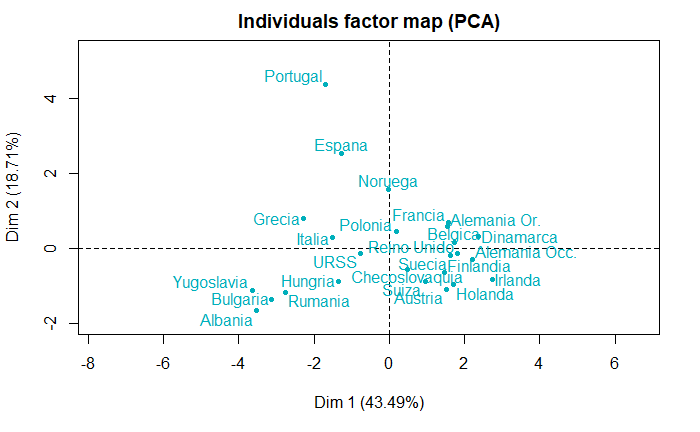

```r
plot(pca_consumo, axes=c(1, 2), choix="ind", col.ind="#00AFBB",new.plot=TRUE)
```

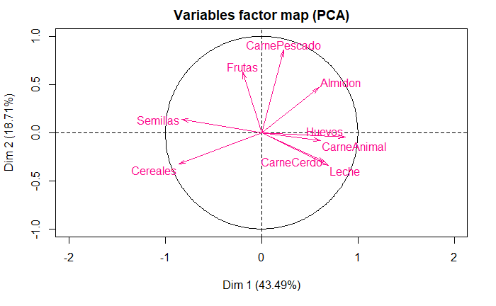

```r
plot(pca_consumo, axes=c(1, 2), choix="var", col.var="#fc078a",new.plot=TRUE)
```

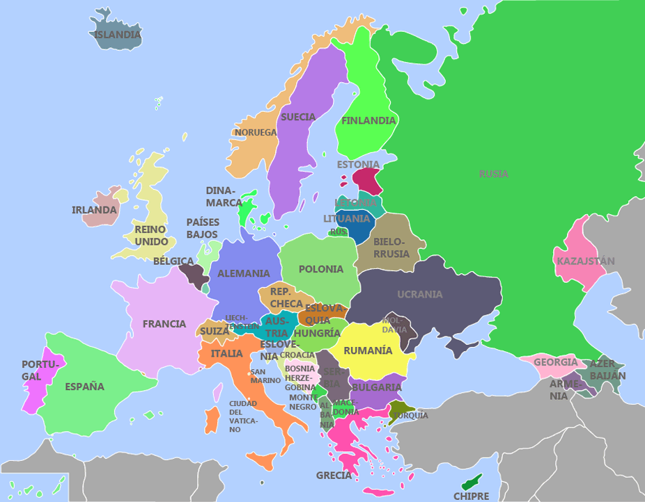